# Research of Non-Spanish players in Real Madrid soccer club

Shuzhi Zeng

# Research of Non-Spanish players in Real Madrid soccer club

## Overview

Real Madrid is a famous soccer club in Spanish League and almost half of its players are from Spain in the history. However, there are also many great players from other countries joined this club in the history, including some of the best players in the world. This data set collects 75 non-Spanish players from 1957-2017 in Real Madrid’s history, and we may be able to find some interesting results by sorting these data. This set can also help the people who love soccer to figure out those greatest players who had ever joined Real Madrid and a tendency of the “bring in” policy of Read Madrid club these years.

## Data dictionary

- **name**: a character variable which shows the full name of each player.
- **nationality**: a categorical variable which illustrates the home country of each player. Possible options are like “Germany”, “China”, “Brazil”, etc.
- **position**: a categorical variable which shows the role of each player in the match. Possible options are like “Forward”, “Defender”, “Midfielder” and “Goalkeeper”.
- **year_join**: a numerical variable which describes the year of each player joined the club.
- **year_leave**: a numerical variable which shows the year of each player left the club (“2018” means that the player is still in the club).

```r
player <- read_csv("https://raw.githubusercontent.com/urstats/stat209-s18-shuzhizeng/master/soccer_.csv")
player
```

```
## # A tibble: 75 x 5
##    name            nationality position   year_join year_leave
##    <chr>           <chr>       <chr>          <int>      <int>
##  1 Achraf Hakimi   Morroco     Defender        2017       2018
##  2 Theo Hernandez  France      Defender        2017       2018
##  3 Mateo Kovacic   Croatia     Midfielder      2015       2018
##  4 Danilo          Brazil      Defender        2015       2017
##  5 Keylor Navas    Costa Rica  Goalkeeper      2014       2018
##  6 James Rodriguez Colombia    Midfielder      2014       2017
##  7 Toni Kroos      Germany     Midfielder      2014       2018
##  8 Gareth Bale     Wales       Midfielder      2013       2018
##  9 Luka Moderic    Croatia     Midfielder      2012       2018
## 10 Casemiro        Brazil      Midfielder      2012       2018
## # ... with 65 more rows
```

## Exploratory Analysis

The graphs below focus on the tendency of players flow in each year. Some relations can also been seen such as nationality and position changings each year. Most of the analysis will focus on the players over year 2000 (21st century), and we can predict the movement of foriegn players in Real Madrid in the future.

```
## # A tibble: 37 x 5
##    name            nationality position   year_join year_leave
##    <chr>           <chr>       <chr>          <int>      <int>
##  1 Achraf Hakimi   Morroco     Defender        2017       2018
##  2 Theo Hernandez  France      Defender        2017       2018
##  3 Mateo Kovacic   Croatia     Midfielder      2015       2018
##  4 Danilo          Brazil      Defender        2015       2017
##  5 Keylor Navas    Costa Rica  Goalkeeper      2014       2018
##  6 James Rodriguez Colombia    Midfielder      2014       2017
##  7 Toni Kroos      Germany     Midfielder      2014       2018
##  8 Gareth Bale     Wales       Midfielder      2013       2018
##  9 Luka Moderic    Croatia     Midfielder      2012       2018
## 10 Casemiro        Brazil      Midfielder      2012       2018
## # ... with 27 more rows
```

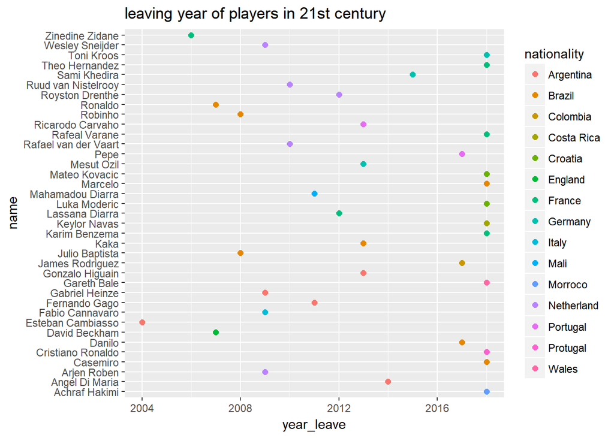

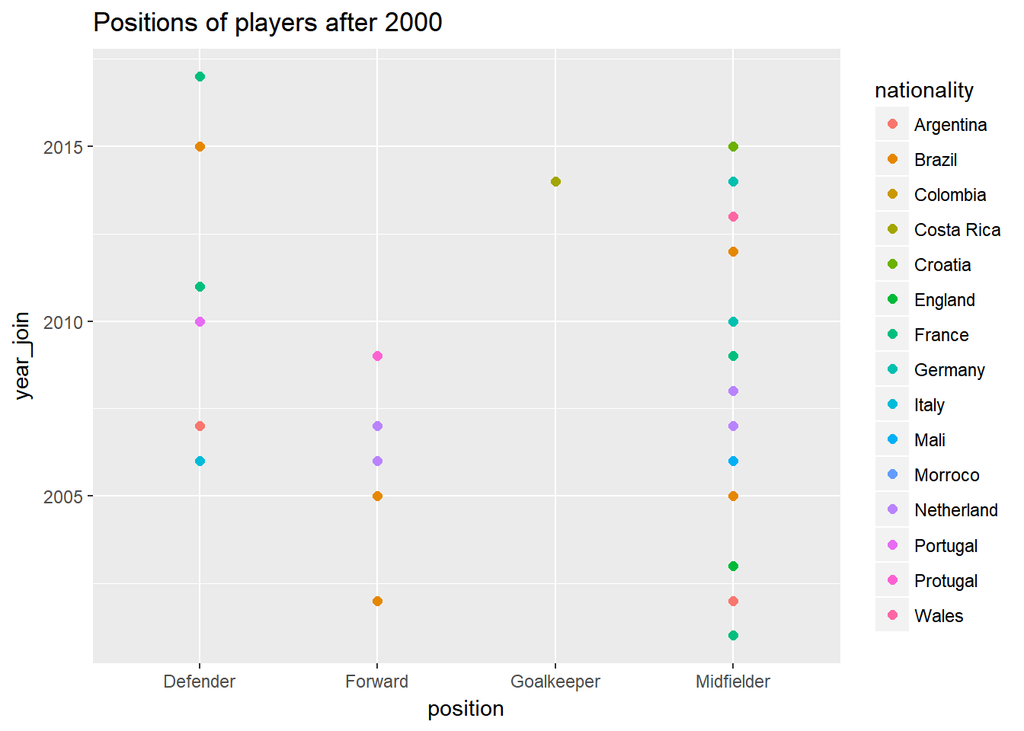

This graph shows the distribution of players postition and the year they joined the club after 2000. It’s obvious that most players joined the club are midfielders, and there’s only one goalkeeper joined the club since 2000. Also the number of amount that players joined each year is around 1-3 players, so there’s no big “bring in” (buy many players in one year) after 2000 .

[output not shown]

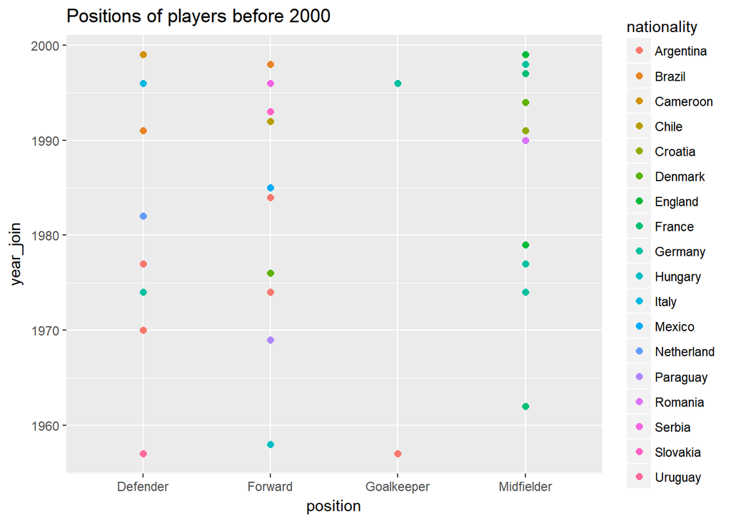

This graph shows the same relation as the previous graph, and the only different is that this graph shows the players from 1957 to 1999, instead of after 2000. So we can make a comparison of the changings between this century and last century. We can see that the amount of “Defender”,“Forward” and “Midfielder” is almost the same, where “Goalkeeper”" is still the least. Also there’s still no big “bring in” in this period of time.

## Conclusion

Overall, we can make a conclusion that comparing with the situation of last century, the club pays more attention in bringing in more “Midfielder” among non-spanish players, and “Goalkeeper” is still very hard to join since there were only 3 new foriegn goalkeepers joined the club from 1957-2017. More players left the club after 2008, but greater players have greater chances to stay in the team. Finally, Real Madrid is not the club who likes to make big “bring in”, so the chances for foriegn players to join the club are still challenging in the future.